# Homework 5

PSTAT 131/231

## Elastic Net Tuning

For this assignment, we will be working with the file `"pokemon.csv"`, found in `/data`. The file is from Kaggle: https://www.kaggle.com/abcsds/pokemon.

The [Pokémon](https://www.pokemon.com/us/) franchise encompasses video games, TV shows, movies, books, and a card game. This data set was drawn from the video game series and contains statistics about 721 Pokémon, or “pocket monsters.” In Pokémon games, the user plays as a trainer who collects, trades, and battles Pokémon to (a) collect all the Pokémon and (b) become the champion Pokémon trainer.

Each Pokémon has a [primary type](https://bulbapedia.bulbagarden.net/wiki/Type) (some even have secondary types). Based on their type, a Pokémon is strong against some types, and vulnerable to others. (Think rock, paper, scissors.) A Fire-type Pokémon, for example, is vulnerable to Water-type Pokémon, but strong against Grass-type.

The goal of this assignment is to build a statistical learning model that can predict the **primary type** of a Pokémon based on its generation, legendary status, and six battle statistics.

Read in the file and familiarize yourself with the variables using `pokemon_codebook.txt`.

```r
library(tidyverse)
library(tidymodels)
tidymodels_prefer()

pokemon_raw <- read_csv('data/Pokemon.csv')
```

### Exercise 1

Install and load the `janitor` package. Use its `clean_names()` function on the Pokémon data, and save the results to work with for the rest of the assignment. What happened to the data? Why do you think `clean_names()` is useful?

```r
library(janitor)

# Added drop_na() as it would not work otherise
pokemon_clean <- clean_names(pokemon_raw)
```

The `clean_names()` function removes spaces from the column names and makes it easier to access the variables. In some cases, this is necessary in order to even access the variables using certain functions. In this case, it just makes the names tidier and easier to work with as well as more consistent in their cases.

### Exercise 2

Using the entire data set, create a bar chart of the outcome variable, `type_1`.

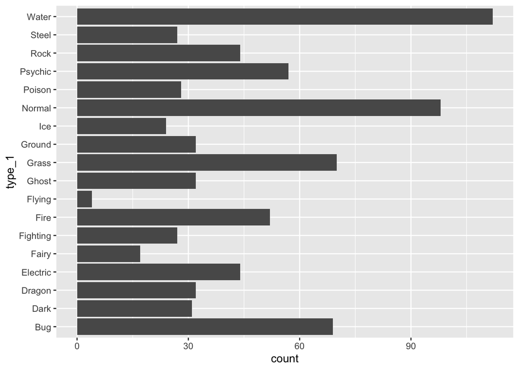

```r
pokemon_clean %>% ggplot(mapping = aes(y = type_1)) + geom_bar()
```

How many classes of the outcome are there? Are there any Pokémon types with very few Pokémon? If so, which ones?

**There are 18 classes of the outcome. There are many types with less than 30 Pokémon, and in particular Flying and Fairy have very low counts.**

For this assignment, we’ll handle the rarer classes by simply filtering them out. Filter the entire data set to contain only Pokémon whose `type_1` is Bug, Fire, Grass, Normal, Water, or Psychic.

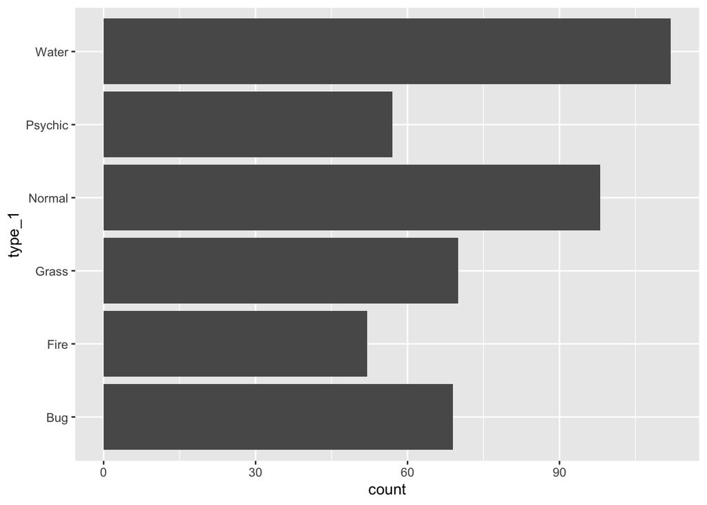

```r
pokemon <- pokemon_clean %>%
  filter(type_1 %in% c('Bug', 'Fire', 'Grass', 'Normal', 'Water', 'Psychic'))

pokemon %>% ggplot(mapping = aes(y = type_1)) + geom_bar()
```

After filtering, convert `type_1` and `legendary` to factors.

```r
pokemon$type_1 <- as.factor(pokemon$type_1)
pokemon$legendary <- as.factor(pokemon$legendary)
#pokemon$generation <- as.factor(pokemon$generation)
```

### Exercise 3

Perform an initial split of the data. Stratify by the outcome variable. You can choose a proportion to use. Verify that your training and test sets have the desired number of observations.

```r
pokemon_split <- initial_split(pokemon, strata=type_1)
pokemon_train <- training(pokemon_split)
pokemon_test <- testing(pokemon_split)
```

Next, use *v*-fold cross-validation on the training set. Use 5 folds. Stratify the folds by `type_1` as well. *Hint: Look for a `strata` argument.* Why might stratifying the folds be useful?

```r
pokemon_folds <- vfold_cv(pokemon_train, v=5, strata=type_1)
```

### Exercise 4

Set up a recipe to predict `type_1` with `legendary`, `generation`, `sp_atk`, `attack`, `speed`, `defense`, `hp`, and `sp_def`.

- Dummy-code `legendary` and `generation`;
- Center and scale all predictors.

```r
pokemon_rec <- pokemon_train %>%
  recipe(type_1 ~ legendary + generation + sp_atk + attack + speed + defense + hp + sp_def) %>%
  step_dummy(all_nominal_predictors()) %>% # Step Dummy
  step_normalize(all_numeric_predictors()) # Center AND Scale
```

### Exercise 5

We’ll be fitting and tuning an elastic net, tuning `penalty` and `mixture` (use `multinom_reg` with the `glmnet` engine).

```r
pokemon_spec <- multinom_reg(penalty = tune(), mixture = tune()) %>%
  set_mode('classification') %>%
  set_engine('glmnet')
```

Set up this model and workflow. Create a regular grid for `penalty` and `mixture` with 10 levels each; `mixture` should range from 0 to 1. For this assignment, we’ll let `penalty` range from -5 to 5 (it’s log-scaled).

```r
pokemon_workflow <- workflow() %>%
  add_recipe(pokemon_rec) %>%
  add_model(pokemon_spec)

pen_mix_grid <- grid_regular(
  penalty(range = c(-5, 5)), mixture(range = c(0, 1)), levels = 10
  )

pen_mix_grid
```

```
## # A tibble: 100 × 2
##          penalty mixture
##            <dbl>   <dbl>
##  1      0.00001        0
##  2      0.000129       0
##  3      0.00167        0
##  4      0.0215         0
##  5      0.278          0
##  6      3.59           0
##  7     46.4            0
##  8    599.             0
##  9   7743.             0
## 10 100000              0
## # … with 90 more rows
```

How many total models will you be fitting when you fit these models to your folded data?

Based on the existence of 100 rows, I am assuming that this would be one model per each set of parameters, then five times each model. Thus 500 total models.

### Exercise 6

Fit the models to your folded data using `tune_grid()`.

```r
tune_res <- tune_grid(
  pokemon_workflow,
  resamples = pokemon_folds,
  grid = pen_mix_grid
)
```

Use `autoplot()` on the results. What do you notice? Do larger or smaller values of `penalty` and `mixture` produce better accuracy and ROC AUC?

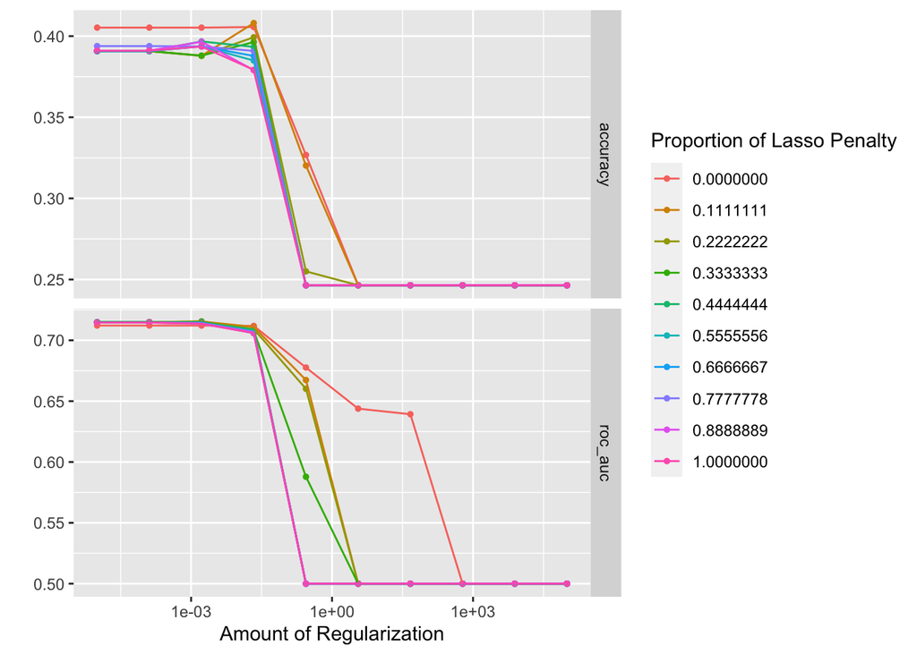

```r
autoplot(tune_res)
```

### Exercise 7

Use `select_best()` to choose the model that has the optimal `roc_auc`. Then use `finalize_workflow()`, `fit()`, and `augment()` to fit the model to the training set and evaluate its performance on the testing set.

```r
best_model <- select_best(tune_res, metric='roc_auc')

pokemon_final <- finalize_workflow(pokemon_workflow, best_model)
pokemon_final_fit <- fit(pokemon_final, data = pokemon_train)

train_results <- augment(pokemon_final_fit, new_data = pokemon_train)
train_results %>%
  accuracy(truth = type_1, estimate=.pred_class)
```

```
## # A tibble: 1 × 3
##   .metric  .estimator .estimate
##   <chr>    <chr>          <dbl>
## 1 accuracy multiclass     0.437
```

```r
train_results %>%
  roc_auc(truth = type_1, estimate=.pred_Bug:.pred_Water)
```

```
## # A tibble: 1 × 3
##   .metric .estimator .estimate
##   <chr>   <chr>          <dbl>
## 1 roc_auc hand_till      0.770
```

### Exercise 8

Calculate the overall ROC AUC on the testing set.

```r
test_results <- augment(pokemon_final_fit, new_data = pokemon_test)

test_results %>%
  roc_auc(type_1, .pred_Bug:.pred_Water)
```

```
## # A tibble: 1 × 3
##   .metric .estimator .estimate
##   <chr>   <chr>          <dbl>
## 1 roc_auc hand_till      0.689
```

Then create plots of the different ROC curves, one per level of the outcome. Also make a heat map of the confusion matrix.

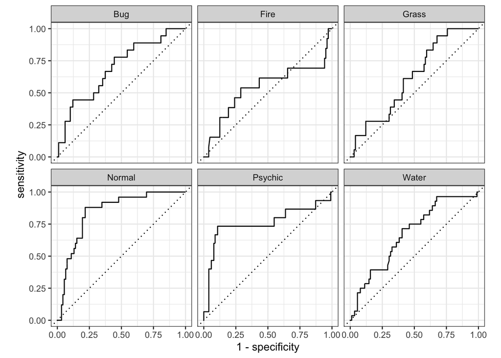

```r
test_results %>%
  roc_curve(type_1, .pred_Bug:.pred_Water) %>%
  autoplot()
```

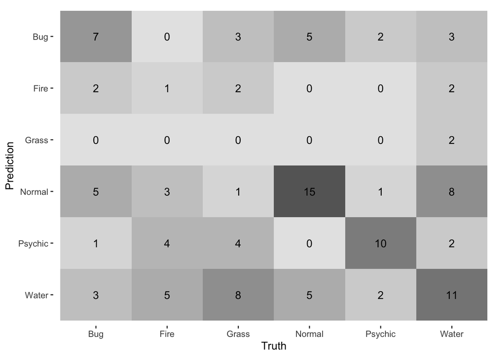

```r
test_results %>%
  conf_mat(truth = type_1, estimate = .pred_class) %>%
  autoplot(type = 'heatmap')
```

What do you notice? How did your model do? Which Pokemon types is the model best at predicting, and which is it worst at? Do you have any ideas why this might be?

## For 231 Students

### Exercise 9

In the 2020-2021 season, Stephen Curry, an NBA basketball player, made 337 out of 801 three point shot attempts (42.1%). Use bootstrap resampling on a sequence of 337 1’s (makes) and 464 0’s (misses). For each bootstrap sample, compute and save the sample mean (e.g. bootstrap FG% for the player). Use 1000 bootstrap samples to plot a histogram of those values. Compute the 99% bootstrap confidence interval for Stephen Curry’s “true” end-of-season FG% using the quantile function in R. Print the endpoints of this interval.